# Categorical Data Analysis

The impact of Digital Marketing in Nigeria

Agbugah Raymond

2025-02-09

# **INTRODUCTION**

Over the last ten years, Nigeria’s e-commerce sector has grown significantly due to rising smart phone usage, middle class expansion, and internet penetration (Ayo et al., 2011; Internet World, 2014). E-commerce companies now depend heavily on digital marketing to help them reach a larger audience, customize consumer interactions, and increase customer engagement (Tiago & Veríssimo, 2014). For the purpose of creating marketing strategies that effectively drive sales and foster client loyalty, it is imperative to comprehend customer behaviour in this digital context. The worldwide business landscape has seen a fundamental transformation due to the swift progress of digital technology, with e-commerce emerging as a crucial industry (Eze, Chinedu-Eze, & Bello, 2019). Nigeria stands out as a prominent site for the expansion of e-commerce, with over 108 million internet users as of 2023 (Statista, 2023). Nigeria had a 43% internet penetration rate at the time, which demonstrated the enormous online audience that was accessible to companies (Adeniran & Nwankwo, 2023). Businesses must use cutting-edge marketing techniques in order to effectively interact with and draw in the increasing number of online customers as a result of the digital revolution. Nigerian companies need to use digital marketing strategies and solutions that cater to the distinct tastes and online habits of the nation’s diversified online population if they want to be competitive in this dynamic industry (Ogunyemi, 2022). Digital marketing, which includes various online platforms including social media, email, search engines, and content marketing, has grown to be a crucial instrument for e-commerce companies seeking to establish a connection with their customers (Chaffey & Ellis-Chadwick, 2019). Since maximizing marketing strategy depends on knowing how these digital marketing approaches affect consumer behavior, there is a great deal of interest in how effective they are at influencing consumer behavior (Smith, 2020). To obtain a competitive edge in the quickly changing Nigerian market, where digital adoption is increasing yet varies across different demographics (Okonkwo, 2021), firms need to develop a sophisticated understanding of how digital marketing affects customer purchasing decisions. Businesses may increase engagement, boost brand perception, and achieve higher sales by adjusting their digital marketing strategies to the distinct interests and behaviors of Nigerian consumers. Previous studies have highlighted how digital marketing has a big impact on consumers’ views and intentions to buy. For example, Chaffey and Ellis-Chadwick (2019) point out that effective digital marketing techniques can raise brand awareness, improve consumer engagement, and eventually increase sales conversions. They contend that customized content and data analytics-driven targeted digital campaigns work especially well at piqueing consumers’ interests and influencing their decisions to buy. Observations from the Nigerian also offer more proof of the influence internet marketing has over customer behavior. According to Okonkwo (2021), social media sites like Facebook, Instagram, and Twitter have a significant impact on how Nigerian consumers make decisions. Through influencer collaborations, interactive content, and targeted adverts, businesses can reach a wide audience, foster brand loyalty, and stimulate purchases thanks to the widespread use and active participation on these platforms. The convergence of regional social media usage and global digital marketing concepts highlights the revolutionary potential of digital marketing in Nigeria’s e-commerce industry. However, research focusing on the subtle effects of digital marketing on customer choice in the Nigerian e-commerce industry is conspicuously lacking. Research that has already been done tends to concentrate on the general effects of digital marketing rather than exploring the particular characteristics of the Nigerian market, such as cultural preferences, economic variables, and rates of technological adoption (Eze et al., 2019). In order to close this gap, this study project will methodically investigate the ways in which Nigerian customers’ purchase decisions are influenced differently by different digital marketing strategies, such as influencer endorsements, email campaigns, mobile marketing, SEO, and social media marketing. The study will offer insightful information that will assist companies in customizing their digital marketing initiatives to more effectively satisfy the demands and preferences of their target audience in Nigeria by thoroughly examining these tactics and evaluating their efficacy in that country.

# **Statement of the Problem**

Notwithstanding Nigeria’s booming e-commerce industry, there is limited research on how digital marketing, in all its forms specifically affects consumer purchase decisions. Research works that specifically speaks on how effective the various digital marketing strategies, including search engine optimization, influencer marketing, content marketing, email marketing, and social media marketing are to the market is largely still insignificant. There is yet still to be an evidence-backed understanding of the consumer behaviours that influences the effectiveness of digital marketing strategies in the country (Eze & Bello, 2016). This study aims to fill this gap by examining what direct impact digital marketing has on consumer purchase decisions in the Nigerian e-commerce sector

# **AIM AND OBJECTIVES OF THE STUDY**

The why of this research proposal is to impact of targeted digital marketing operations has on whether a consumer will buy an item or patronise a service on not. This will offer significant economic value to ecommerce businesses operating within the country as it will provide insights into what strategies works, points of contacts and interaction with the various mediums and apparatus within which their digital marketing operations are carried out. The objectives of the research are:

1. To examine how digital marketing strategies impact consumer purchase decisions in the Nigerian e-commerce market.
2. To evaluate the impact of consumer satisfaction and loyalty in response to digital marketing strategies.

1.To identify the most effective digital marketing used by Nigerian e.commerce platform.

# **DATA IMPORTATION**

|  | Timestamp | Demographics..What.is.your.age. | What.is.your.gender | What.is.your.highest.level.of.education. | What.is.your.monthly.income. | How.often.do.you.hear.about.strategies.digital.marketing. | Which.e.commerce.platforms.do.you.frequently.use. | How.do.you.usually.find.out.about.products.or.services.online. | What.type.of.digital.marketing.content.influences.your.purchase.decision.the.most. | How.much.do.online.reviews.impact.your.decision.to.purchase.a.product. | How.likely.are.you.to.purchase.a.product.due.to.advertisement.you.saw.on.social.media. | How.likely.are.you.to.purchase.a.product.due.to.advertisement.you.saw.in.your.email. | How.likely.are.you.to.purchase.a.product.you.saw.due.to.content.marketing.you.saw. | How.likely.are.you.to.purchase.a.product.you.saw.advertised.in.Mobile.Marketing. | How.likely.are.you.to.purchase.a.good.you.used.Search.Engine.Optimization.to.find. | How.likely.are.you.to.purchase.a.good.displayed.by.image.with.or.without.caption. | How.likely.are.you.to.purchase.a.good.you.found.on.sponsored.Ads. | How.much.do.personalized.advertisements.impact.your.buying.decision. | Do.discounts.or.promotions.seen.online.influence.your.purchase.decisions. | How.satisfied.are.you.with.the.online.shopping.experiences.you.have.had.in.the.past.one.month.or.two. | How.likely.are.you.to.recommend.an.e.commerce.platform.to.others.based.on.your.satisfaction.with.their.digital.marketing. | Does.a.positive.online.shopping.experience.increase.your.loyalty.to.a.particular.e.commerce.platform. | How.often.do.you.return.to.the.same.e.commerce.platform.for.future.purchases.due.to.their.effective.digital.marketing.strategies. | Which.digital.marketing.strategies.do.you.find.most.effective.in.engaging.you. | How.do.you.rate.the.effectiveness.of.social.media.campaigns.in.driving.your.purchase.decisions. | How.effective.do.you.find.influencer.marketing.in.affecting.your.purchasing.choices. | In.your.opinion..which.e.commerce.platform.has.the.most.effective.digital.marketing.strategy. |
| --- | --- | --- | --- | --- | --- | --- | --- | --- | --- | --- | --- | --- | --- | --- | --- | --- | --- | --- | --- | --- | --- | --- | --- | --- | --- | --- | --- |
| 1 | 8/6/2024 7:42 | 18 - 25 | Female | Tertiary | #100,000 - #200,000 | Always | AliExpress | Search Engines | Images | Significantly | Moderately likely | Not likely | Slightly likely | Slightly likely | Slightly likely | Not likely | Not likely | Moderatly | Sometimes | Satisfied | Moderately likely | Significantly | Sometimes | Content Marketing | Effective | Effective | AliExpress |
| 2 | 8/6/2024 8:16 | 18 - 25 | Male | Tertiary | #50,000 - #100,000 | Sometimes | Jumia, AliExpress | Social Media | Social Media Marketing | Significantly | Very likely | Moderately likely | Very likely | Very likely | Very likely | Very likely | Very likely | Significantly | Often | Very satisfied | Very likely | Significantly | Often | Search Engine Optimization | Effective | Effective | Jumia |
| 3 | 8/6/2024 9:15 | 26 - 35 | Female | Postgraduate | #50,000 - #100,000 | Often | Jumia | Online Ads | Images | Extremely | Very likely | Not likely | Slightly likely | Slightly likely | Not likely | Not likely | Not likely | Significantly | Rarely | Neutral | Slightly likely | Slightly | Rarely | Search Engine Optimization | Ineffective | Ineffective | Jumia |
| 4 | 8/6/2024 9:23 | 26 - 35 | Female | Tertiary | #50,000 - #100,000 | Often | Konga | Social Media | Images | Slightly | Not likely | Slightly likely | Not likely | Not likely | Slightly likely | Slightly likely | Slightly likely | Slightly | Rarely | Dissatisfied | Slightly likely | Slightly | Never | Content Marketing | Ineffective | Ineffective | Jumia |
| 5 | 8/6/2024 9:24 | 18 - 25 | Female | Tertiary | Less than #50,000 | Rarely | Jumia | Email Marketing | Images | Not at all | Not likely | Slightly likely | Not likely | Not likely | Not likely | Not likely | Not likely | Not at all | Rarely | Very satisied | Slightly likely | Slightly | Rarely | Email Marrketing | Very ineffective | Very ineffective | Konga |
| 6 | 8/6/2024 9:25 | 18 - 25 | Female | Tertiary | Less than #50,000 | Sometimes | Konga | Social Media | Videos | Not at all | Slightly | Not likely | Moderately likely | Slightly likely | Slightly likely | Slightly likely | Slightly likely | Slightly | Sometimes | Very satisied | Slightly likely | Slightly | Rarely | Pay Per Click | Neutral | Ineffective | Jumia |
| 7 | 8/6/2024 9:26 | 18 - 25 | Female | Tertiary | Less than #50,000 | Rarely | Konga | Search Engines | Images | Slightly | Not likely | Not likely | Not likely | Slightly likely | Slightly likely | Slightly likely | Slightly likely | Slightly | Never | Neutral | Moderately likely | Moderately | Rarely | Content Marketing | Ineffective | Ineffective | Jumia |
| 8 | 8/6/2024 9:27 | 26 - 35 | Male | Tertiary | #50,000 - #100,000 | Rarely | Jumia | Social Media | Videos | Slightly | Not likely | Slightly likely | Moderately likely | Moderately likely | Moderately likely | Slightly likely | Moderately likely | Significantly | Sometimes | Neutral | Moderately likely | Moderately | Rarely | Content Marketing | Ineffective | Ineffective | AliExpress |
| 9 | 8/6/2024 9:29 | 18 - 25 | Female | Secondary | Less than #50,000 | Never | Jumia | Social Media | Videos | Not at all | Not likely | Slightly likely | Not likely | Not likely | Not likely | Not likely | Slightly likely | Moderatly | Never | Very satisied | Not likely | Not at all | Rarely | Email Marrketing | Ineffective | Very ineffective | Amazon |
| 10 | 8/6/2024 9:31 | 36 - 35 | Male | Postgraduate | #200,000 - #500,000 | Often | Amazon | Email Marketing | Sponsored Ads | Significantly | Not likely | Very likely | Not likely | Not likely | Slightly likely | Slightly likely |  | Not at all | Never | Dissatisfied | Slightly likely | Slightly | Never | Email Marrketing | Very ineffective | Very ineffective | Amazon |

[output cut: 441 more lines]

# **DEFINITION OF TERMS**

1. Let marketinfluence =What.type.of.digital.marketing.content.influences.your.purchase.decision.the.most.
2. Let Onlinereview_impact = How.much.do.online.reviews.impact.your.decision.to.purchase.a.product
3. Let Purchasesocial.media = How.likely.are.you.to.purchase.a.product.due.to.advertisement.you.saw.on.social.media.
4. Let Productcontent = How.likely.are.you.to.purchase.a.product.you.saw.due.to.content.marketing.you.saw.
5. Let satisfied_online.shopping = How.satisfied.are.you.with.the.online.shopping.experiences.you.have.had.in.the.past.one.month.or.two.
6. Let marketstrategy = Which.digital.marketing.strategies.do.you.find.most.effective.in.engaging.you.
7. Let freqused_ecomerce = Which.e.commerce.platforms.do.you.frequently.use

1.Let returnsameecommerce= How.often.do.you.return.to.the.same.e.commerce.platform.for.future.purchases.due.to.their.effective.digital.marketing.strategies.

1. Let discountpromo =Do.discounts.or.promotions.seen.online.influence.your.purchase.decisions
2. let satisfaction=How.satisfied.are.you.with.the.online.shopping.experiences.you.have.had.in.the.past.one.month.or.two.
3. Let recommend.ecom = toHow.likely.are.you.to.recommend.an.e.commerce.platform.others.based.on.your.satisfaction.with.their.digital.marketing.
4. Let rate = How.do.you.rate.the.effectiveness.of.social.media.campaigns.in.driving.your.purchase.decisions.

1.let influencermarketing= How.effective.do.you.find.influencer.marketing.in.affecting.your.purchasing.choices.

1. mosteffective=In.your.opinion..which.e.commerce.platform.has.the.most.effective.digital.marketing.strategy.

# **RENAMING OF COLUMNS**

|  | freqused_ecomerce | market_influence | Online.review_impact | Purchase_social.media | Product_content | discount_promo | satisfaction | recommend.ecom | return_sameecommerce | market_strategy | rate | influencer.marketing | most_effective |
| --- | --- | --- | --- | --- | --- | --- | --- | --- | --- | --- | --- | --- | --- |
| 1 | AliExpress | Images | Significantly | Moderately likely | Slightly likely | Sometimes | Satisfied | Moderately likely | Sometimes | Content Marketing | Effective | Effective | AliExpress |
| 2 | Jumia, AliExpress | Social Media Marketing | Significantly | Very likely | Very likely | Often | Very satisfied | Very likely | Often | Search Engine Optimization | Effective | Effective | Jumia |
| 3 | Jumia | Images | Extremely | Very likely | Slightly likely | Rarely | Neutral | Slightly likely | Rarely | Search Engine Optimization | Ineffective | Ineffective | Jumia |
| 4 | Konga | Images | Slightly | Not likely | Not likely | Rarely | Dissatisfied | Slightly likely | Never | Content Marketing | Ineffective | Ineffective | Jumia |
| 5 | Jumia | Images | Not at all | Not likely | Not likely | Rarely | Very satisied | Slightly likely | Rarely | Email Marrketing | Very ineffective | Very ineffective | Konga |
| 6 | Konga | Videos | Not at all | Slightly | Moderately likely | Sometimes | Very satisied | Slightly likely | Rarely | Pay Per Click | Neutral | Ineffective | Jumia |
| 7 | Konga | Images | Slightly | Not likely | Not likely | Never | Neutral | Moderately likely | Rarely | Content Marketing | Ineffective | Ineffective | Jumia |
| 8 | Jumia | Videos | Slightly | Not likely | Moderately likely | Sometimes | Neutral | Moderately likely | Rarely | Content Marketing | Ineffective | Ineffective | AliExpress |
| 9 | Jumia | Videos | Not at all | Not likely | Not likely | Never | Very satisied | Not likely | Rarely | Email Marrketing | Ineffective | Very ineffective | Amazon |
| 10 | Amazon | Sponsored Ads | Significantly | Not likely | Not likely | Never | Dissatisfied | Slightly likely | Never | Email Marrketing | Very ineffective | Very ineffective | Amazon |

[output cut: 441 more lines]

# **DATA ANALYSIS**

|  | Var1 | Var2 | Freq |
| --- | --- | --- | --- |
|  |  | freqused_ecomerce | Jumia :136 |
|  |  | freqused_ecomerce | Konga :103 |
|  |  | freqused_ecomerce | Amazon : 85 |
|  |  | freqused_ecomerce | AliExpress : 68 |
|  |  | freqused_ecomerce | Jumia, AliExpress : 16 |
|  |  | freqused_ecomerce | Others (Please, indicate): 9 |
|  |  | freqused_ecomerce | (Other) : 34 |
|  |  | market_influence | Videos :113 |
|  |  | market_influence | Images : 84 |
|  |  | market_influence | Content Marketing : 63 |

[output cut: 81 more lines]

From the table, you understand that it explains the counts of each of the variables. For example, you observe that 136 people frequently use jumia, 103 people frequently use konga as their e.commerce platform etc, in the table you notice that 113 people are been influenced by videos,84 by images,63 by content marketing etc for their purchase decisions.

| Var1 | Freq |
| --- | --- |
| AliExpress | 0.1507761 |
| Amazon | 0.1884701 |
| Amazon, AliExpress | 0.0155211 |
| Jumia | 0.3015521 |
| Jumia, AliExpress | 0.0354767 |
| Jumia, Amazon | 0.0177384 |
| Jumia, Amazon, AliExpress | 0.0155211 |
| Jumia, Konga | 0.0022173 |
| Jumia, Konga, Amazon, AliExpress | 0.0133038 |
| Jumia, Others (Please, indicate) | 0.0044346 |
| Konga | 0.2283814 |
| Konga, Amazon | 0.0022173 |
| Others | 0.0044346 |
| Others (Please, indicate) | 0.0199557 |

[figure not shown]

| Var1 | Freq |
| --- | --- |
| Content Marketing | 0.1396896 |
| Email Marketing | 0.0266075 |
| Images | 0.1862528 |
| Mobile Marketing | 0.1064302 |
| Reviews | 0.1108647 |
| Search Engine Optimization | 0.0310421 |
| Social Media Marketing | 0.1019956 |
| Sponsored Ads | 0.0465632 |
| Videos | 0.2505543 |

[figure not shown]

| Var1 | Freq |
| --- | --- |
| Extremely | 0.0820399 |
| Moderately | 0.2572062 |
| Not at all | 0.1286031 |
| Significantly | 0.2461197 |
| Slightly | 0.2860310 |

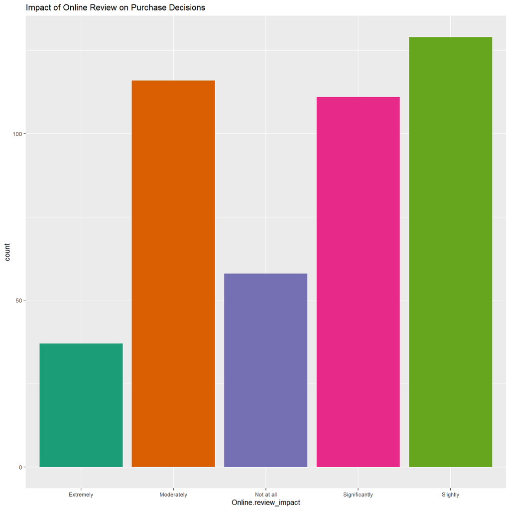

From the analysis you discover that 8.2% of the entire population are extremely impacted by online review, 25.7% are moderately impacted, 12.9% are not impacted at all by online review, 24.6% are significantly while 28.6% are slightly impacted by online review.

| Var1 | Freq |
| --- | --- |
| Extremely likely | 0.0288248 |
| Moderately likely | 0.3392461 |
| Not likely | 0.3436807 |
| Slightly | 0.1108647 |
| Very likely | 0.1773836 |

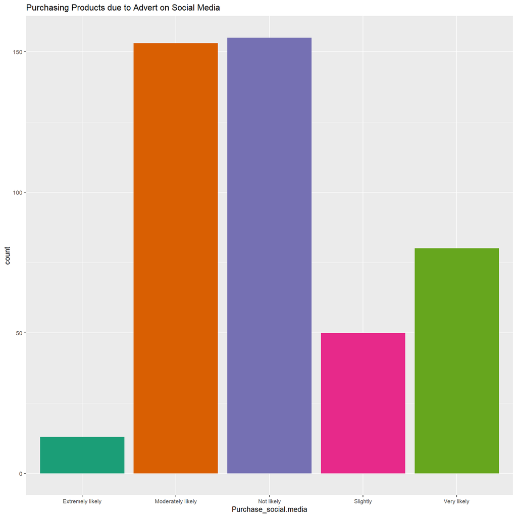

Looking at the Analysis you will see that 2.9% of the population are extremely likely to purchase a product they saw on social media,33.9% are moderately likely to purchase a product on media, 34.4% are not likely to purchase a product due to advert on social media, 11.1 are slightly likely to purchase a product due to advert on social media while 17.7 are very likely to purchase a product due to advert they saw on social media.

| Var1 | Freq |
| --- | --- |
| Extremely likely | 0.0155211 |
| Moderately likely | 0.3414634 |
| Not likely | 0.2372506 |
| Slightly likely | 0.2239468 |
| Very likely | 0.1818182 |

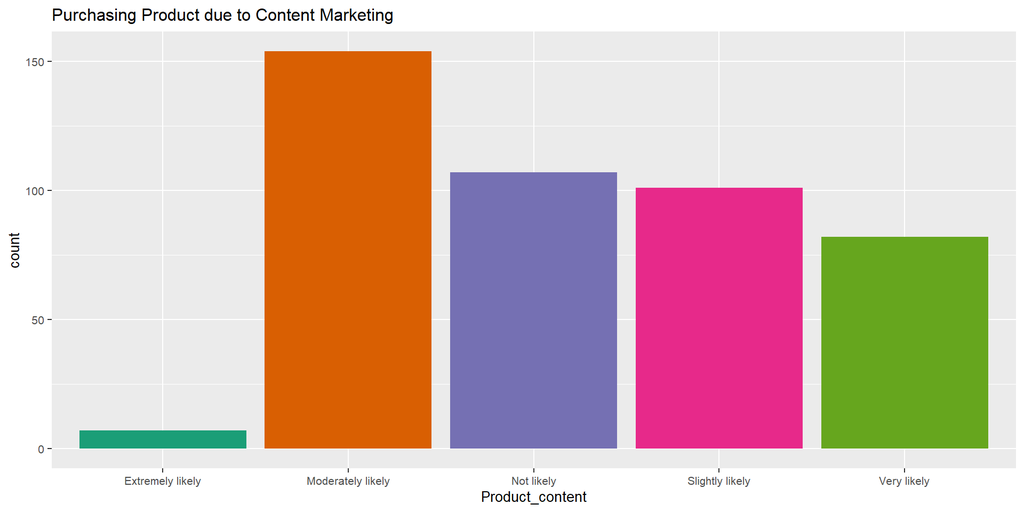

The result shows that 1.6% of the population are extremely likely to purchase a product due to content marketing, 34.1% are moderately likely to purchase a product due to content marketing, 23.7% are not likely to purchase a product due to content marketing, 22.4% are slightly likely to purchase a product due to content marketing while 18.2% are very likely to purchase a product due to content marketing.

| Var1 | Freq |
| --- | --- |
| Dissatisfied | 0.2039911 |
| Neutral | 0.4146341 |
| Satisfied | 0.2239468 |
| Very satisfied | 0.0332594 |
| Very satisied | 0.1241685 |

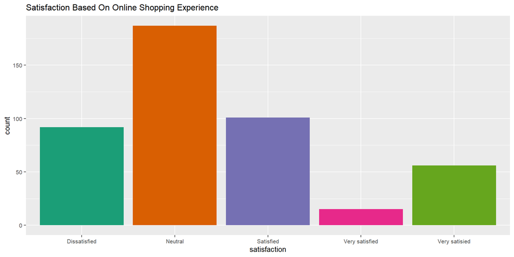

| Var1 | Freq |
| --- | --- |
| Content Marketing | 0.5432373 |
| Email Marrketing | 0.1485588 |
| Google Analytics | 0.0155211 |
| Pay Per Click | 0.0177384 |
| Search Engine Optimization | 0.2749446 |

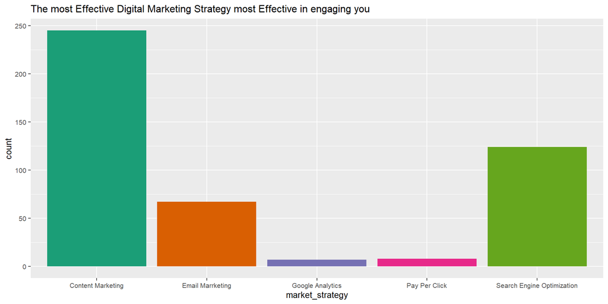

As seen in the result, 54.3% subscribe to content marketing, 14.9% subscribe to email marketing, 1.6% subscribe to Google Analytics, 1.8% subscribe to pay per click and 27.5% subscribe to search engine optimization.

| Var1 | Freq |
| --- | --- |
| Always | 0.0753880 |
| Never | 0.0753880 |
| Often | 0.2084257 |
| Rarely | 0.2682927 |
| Sometimes | 0.3725055 |

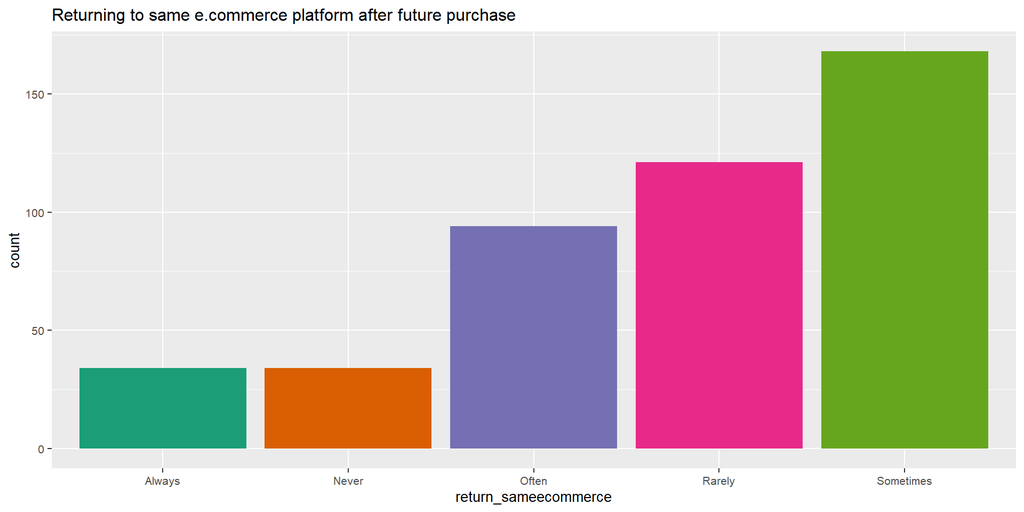

From the result, 7.5% always return to same e.commerce platform for future purchase,7.5% never return to same e.commerce platform, 20.8% often to same e.commerce platform, 26.8% rarely return to same e.commerce while 37.3 sometimes return to same e.commerce platform for future purchase due to their effective marketing strategies.

| Var1 | Freq |
| --- | --- |
| Always | 0.0620843 |
| Never | 0.1108647 |
| Often | 0.1241685 |
| Rarely | 0.2594235 |
| Sometimes | 0.4434590 |

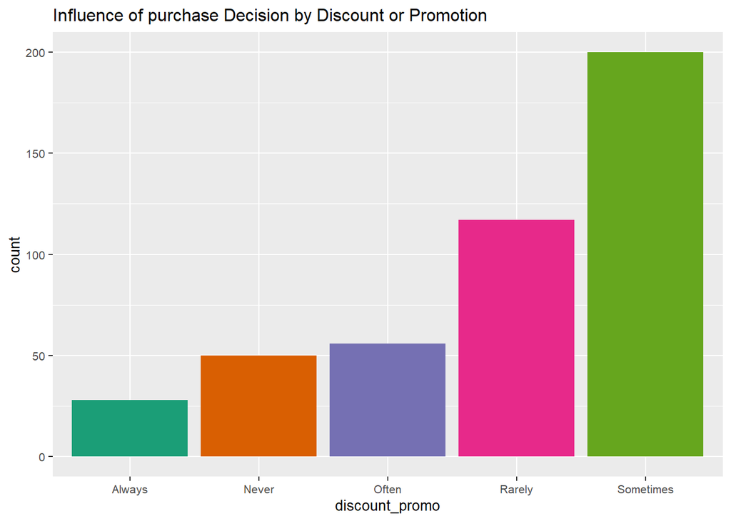

The result shows that 6.2% are always influence by discount and promotion seen online to make their purchase decisions, 11.1% are not influence by discount or promotions seen online to make their purchase decisions,12.4% are often influence by discount and promotions, 25.9% are rarely influenced while 44.3% are sometimes influenced by discount or promotion seen online.

| Var1 | Freq |
| --- | --- |
| Extremely likely | 0.0288248 |
| Moderately likely | 0.3747228 |
| Not likely | 0.0665188 |
| Slightly likely | 0.3259424 |
| Very likely | 0.2039911 |

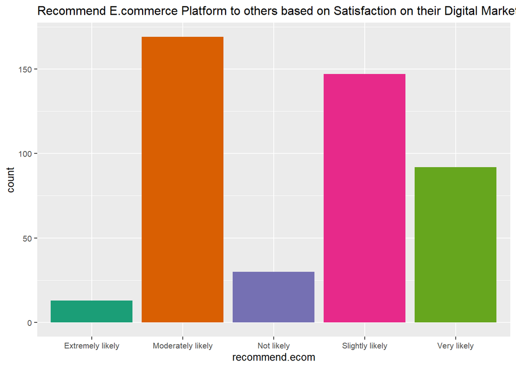

The analysis shows that 2.9% are extremely likely to recommend based on satisfaction on digital marketing,37.5% are moderately likely to recommend e.commerce based on satisfactions, 6.7% are not like to recommend e.commerce platform based on their satisfaction, 32.6% are slightly likely to recommend e.commerce platform based on satisfaction while 20.4% are very likely to recommend e.commerce platform based on their satisfaction on their digital marketing.

| Var1 | Freq |
| --- | --- |
| Effective | 0.2350333 |
| Ineffective | 0.2749446 |
| Neutral | 0.2372506 |
| Very effective | 0.1419069 |
| Very ineffective | 0.1108647 |

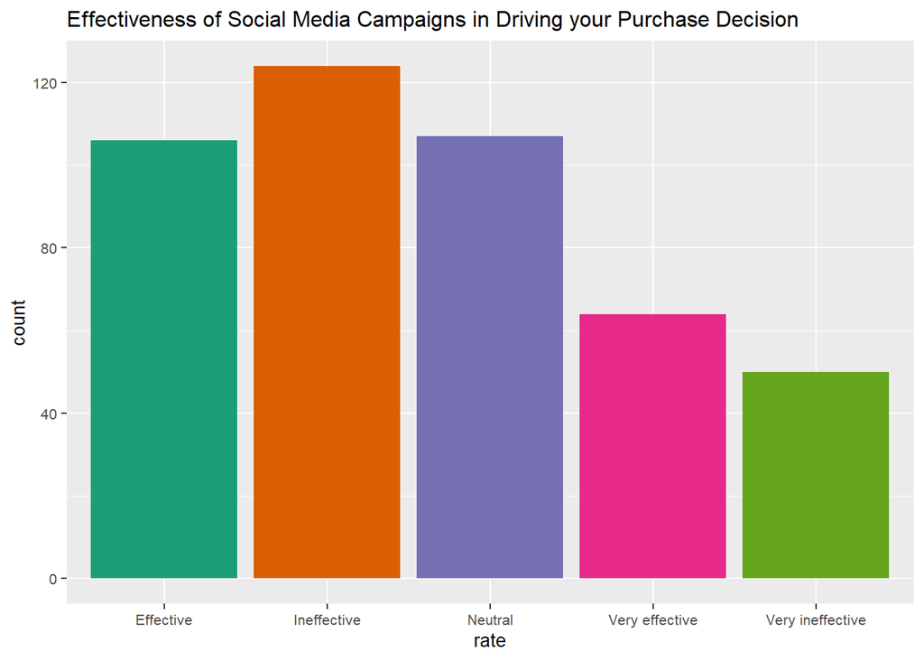

| Var1 | Freq |
| --- | --- |
| Effective | 0.3835920 |
| Ineffective | 0.4035477 |
| Very effective | 0.0975610 |
| Very ineffective | 0.1152993 |

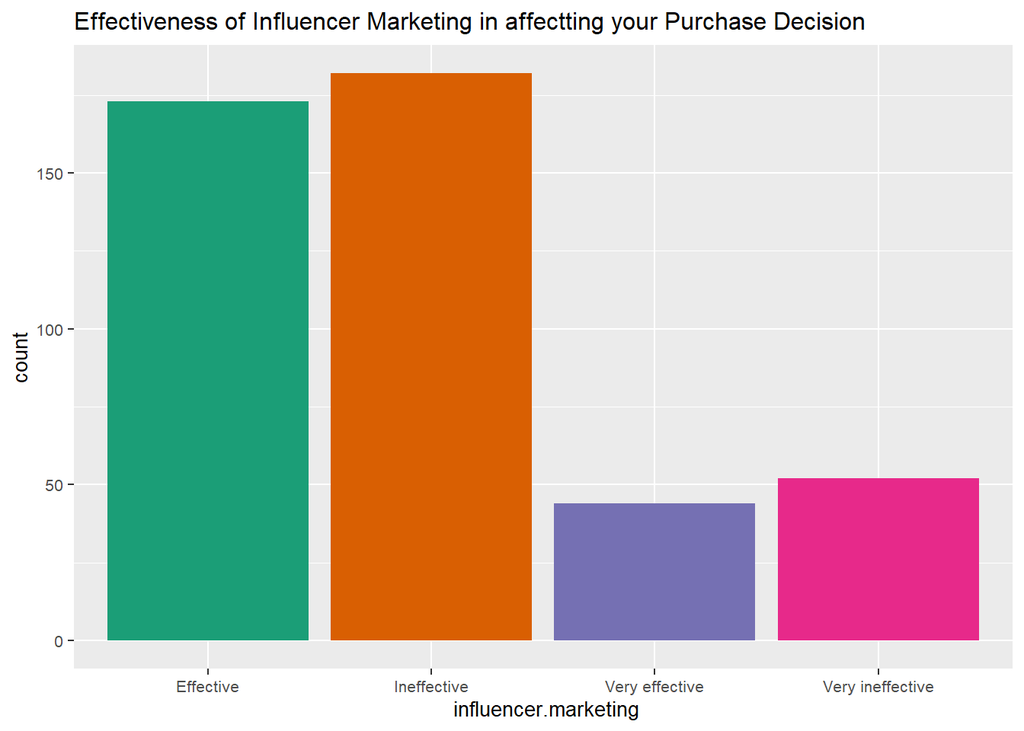

| Var1 | Freq |
| --- | --- |
| AliExpress | 0.1640798 |
| Amazon | 0.3281596 |
| I don’t know | 0.0133038 |
| I have no used any | 0.0155211 |
| Jumia | 0.3769401 |
| Konga | 0.0753880 |
| Option 5 | 0.0266075 |

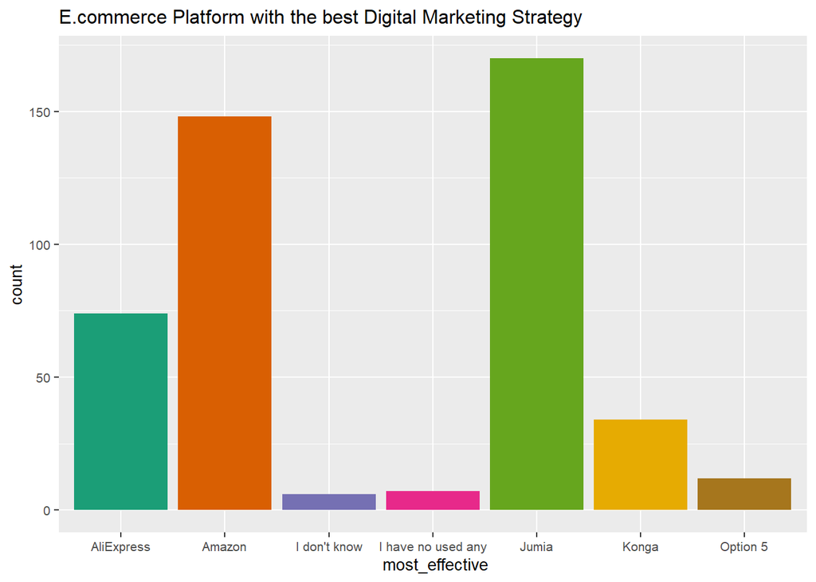

From the results the e.commerce platform with the best digital marketing strategy is Jumia then followed by Amazon.

```
##
##
##    Cell Contents
## |-------------------------|
## |                       N |
## | Chi-square contribution |
## |           N / Row Total |
## |           N / Col Total |
## |         N / Table Total |
## |-------------------------|
##
##
## Total Observations in Table:  451
##
##
##                            | dan_work1$return_sameecommerce
##  dan_work1$market_strategy |    Always |     Never |     Often |    Rarely | Sometimes | Row Total |
## ---------------------------|-----------|-----------|-----------|-----------|-----------|-----------|
##          Content Marketing |        14 |        16 |        36 |        74 |       105 |       245 |
##                            |     1.082 |     0.330 |     4.444 |     1.040 |     2.067 |           |
##                            |     0.057 |     0.065 |     0.147 |     0.302 |     0.429 |     0.543 |
##                            |     0.412 |     0.471 |     0.383 |     0.612 |     0.625 |           |
##                            |     0.031 |     0.035 |     0.080 |     0.164 |     0.233 |           |
## ---------------------------|-----------|-----------|-----------|-----------|-----------|-----------|
##           Email Marrketing |        13 |        14 |         2 |        22 |        16 |        67 |
##                            |    12.510 |    15.855 |    10.251 |     0.901 |     3.215 |           |
##                            |     0.194 |     0.209 |     0.030 |     0.328 |     0.239 |     0.149 |
##                            |     0.382 |     0.412 |     0.021 |     0.182 |     0.095 |           |
##                            |     0.029 |     0.031 |     0.004 |     0.049 |     0.035 |           |
## ---------------------------|-----------|-----------|-----------|-----------|-----------|-----------|
##           Google Analytics |         0 |         2 |         5 |         0 |         0 |         7 |
##                            |     0.528 |     4.108 |     8.594 |     1.878 |     2.608 |           |
##                            |     0.000 |     0.286 |     0.714 |     0.000 |     0.000 |     0.016 |
##                            |     0.000 |     0.059 |     0.053 |     0.000 |     0.000 |           |
##                            |     0.000 |     0.004 |     0.011 |     0.000 |     0.000 |           |
## ---------------------------|-----------|-----------|-----------|-----------|-----------|-----------|
##              Pay Per Click |         0 |         0 |         0 |         7 |         1 |         8 |
##                            |     0.603 |     0.603 |     1.667 |    10.976 |     1.316 |           |
##                            |     0.000 |     0.000 |     0.000 |     0.875 |     0.125 |     0.018 |
##                            |     0.000 |     0.000 |     0.000 |     0.058 |     0.006 |           |
##                            |     0.000 |     0.000 |     0.000 |     0.016 |     0.002 |           |
## ---------------------------|-----------|-----------|-----------|-----------|-----------|-----------|
## Search Engine Optimization |         7 |         2 |        51 |        18 |        46 |       124 |
##                            |     0.590 |     5.776 |    24.484 |     7.007 |     0.001 |           |
##                            |     0.056 |     0.016 |     0.411 |     0.145 |     0.371 |     0.275 |
##                            |     0.206 |     0.059 |     0.543 |     0.149 |     0.274 |           |
##                            |     0.016 |     0.004 |     0.113 |     0.040 |     0.102 |           |
## ---------------------------|-----------|-----------|-----------|-----------|-----------|-----------|
##               Column Total |        34 |        34 |        94 |       121 |       168 |       451 |
##                            |     0.075 |     0.075 |     0.208 |     0.268 |     0.373 |           |
## ---------------------------|-----------|-----------|-----------|-----------|-----------|-----------|
##
##
```

```
##
##
##    Cell Contents
## |-------------------------|
## |                       N |
## | Chi-square contribution |
## |           N / Row Total |
## |           N / Col Total |
## |         N / Table Total |
## |-------------------------|
##
##
## Total Observations in Table:  451
##
##
##                        | dan_work1$discount_promo
## dan_work1$satisfaction |    Always |     Never |     Often |    Rarely | Sometimes | Row Total |
## -----------------------|-----------|-----------|-----------|-----------|-----------|-----------|
##           Dissatisfied |         0 |        22 |         0 |        49 |        21 |        92 |
##                        |     5.712 |    13.653 |    11.424 |    26.466 |     9.608 |           |
##                        |     0.000 |     0.239 |     0.000 |     0.533 |     0.228 |     0.204 |
##                        |     0.000 |     0.440 |     0.000 |     0.419 |     0.105 |           |
##                        |     0.000 |     0.049 |     0.000 |     0.109 |     0.047 |           |
## -----------------------|-----------|-----------|-----------|-----------|-----------|-----------|
##                Neutral |         7 |        13 |        25 |        46 |        96 |       187 |
##                        |     1.830 |     2.883 |     0.137 |     0.130 |     2.061 |           |
##                        |     0.037 |     0.070 |     0.134 |     0.246 |     0.513 |     0.415 |
##                        |     0.250 |     0.260 |     0.446 |     0.393 |     0.480 |           |
##                        |     0.016 |     0.029 |     0.055 |     0.102 |     0.213 |           |
## -----------------------|-----------|-----------|-----------|-----------|-----------|-----------|
##              Satisfied |         8 |         6 |        24 |        10 |        53 |       101 |
##                        |     0.477 |     2.412 |    10.470 |    10.018 |     1.505 |           |
##                        |     0.079 |     0.059 |     0.238 |     0.099 |     0.525 |     0.224 |
##                        |     0.286 |     0.120 |     0.429 |     0.085 |     0.265 |           |
##                        |     0.018 |     0.013 |     0.053 |     0.022 |     0.118 |           |
## -----------------------|-----------|-----------|-----------|-----------|-----------|-----------|
##         Very satisfied |         6 |         0 |         7 |         2 |         0 |        15 |
##                        |    27.588 |     1.663 |    14.171 |     0.919 |     6.652 |           |
##                        |     0.400 |     0.000 |     0.467 |     0.133 |     0.000 |     0.033 |
##                        |     0.214 |     0.000 |     0.125 |     0.017 |     0.000 |           |
##                        |     0.013 |     0.000 |     0.016 |     0.004 |     0.000 |           |
## -----------------------|-----------|-----------|-----------|-----------|-----------|-----------|
##          Very satisied |         7 |         9 |         0 |        10 |        30 |        56 |
##                        |     3.570 |     1.255 |     6.953 |     1.411 |     1.075 |           |
##                        |     0.125 |     0.161 |     0.000 |     0.179 |     0.536 |     0.124 |
##                        |     0.250 |     0.180 |     0.000 |     0.085 |     0.150 |           |
##                        |     0.016 |     0.020 |     0.000 |     0.022 |     0.067 |           |
## -----------------------|-----------|-----------|-----------|-----------|-----------|-----------|
##           Column Total |        28 |        50 |        56 |       117 |       200 |       451 |
##                        |     0.062 |     0.111 |     0.124 |     0.259 |     0.443 |           |
## -----------------------|-----------|-----------|-----------|-----------|-----------|-----------|
##
##
```

# **CONCLUSION**